# Análisis Predictivo en Business Intelligence: regresión en Python

Autor/a

Fernando Salcedo Mejía Eco, Ms

Fecha de publicación

1 de febrero de 2026

Este notebook desarrolla en Python el caso de estudio de regresión de la presentación **Análisis Predictivo en Business Intelligence**. El modelo se estima con [**statsmodels**](https://www.statsmodels.org/) y los datos se manipulan con **pandas**. Es la versión en Python del notebook de regresión en R: usa los mismos datos y llega a los mismos resultados.

Las funciones de statsmodels que se usan con un modelo de regresión lineal son:

| Función | Equivalente en R | Para qué sirve |
| --- | --- | --- |
| `smf.ols(...).fit()` | `lm()` | Estimar la regresión lineal por mínimos cuadrados |
| `.summary()` | `summary()` | Ver coeficientes, errores estándar, valores p y $R^2$ |
| `.params`, `.conf_int()` | `coef()`, `confint()` | Extraer los coeficientes y sus intervalos de confianza |
| `.pvalues`, `.rsquared` | `summary()` | Extraer los valores p y el $R^2$ |
| `.predict()` | `predict()` | Pronosticar la respuesta para datos nuevos |

```python
import matplotlib.pyplot as plt
import numpy as np
import pandas as pd
import seaborn as sns
import statsmodels.formula.api as smf

sns.set_theme(style="whitegrid", font_scale=1.1)
pd.set_option("display.precision", 3)
```

# 1 Estimación y pronóstico de la demanda

La gerencia de una tienda de electrónica quiere ajustar los precios de sus cinco productos estrella para el próximo trimestre. Para anticipar el efecto en las ventas se estima la **elasticidad precio de la demanda** de cada producto con un modelo log-log:

$$\ln(Q) = \beta_1 + \beta_2 \ln(P) + \varepsilon, \qquad E_p = \beta_2$$

## 1.1 Datos

Ventas mensuales de cada producto entre 2016 y 2023.

```python
ventas = pd.read_csv("datos/ventas_electronica.csv", parse_dates=["fecha"])
ventas.head()
```

|  | producto | fecha | precio | cantidad |
| --- | --- | --- | --- | --- |
| 0 | Audífonos | 2016-01-01 | 85.16 | 4768 |
| 1 | Audífonos | 2016-02-01 | 70.28 | 8011 |
| 2 | Audífonos | 2016-03-01 | 81.35 | 4688 |
| 3 | Audífonos | 2016-04-01 | 79.19 | 4429 |
| 4 | Audífonos | 2016-05-01 | 73.85 | 7937 |

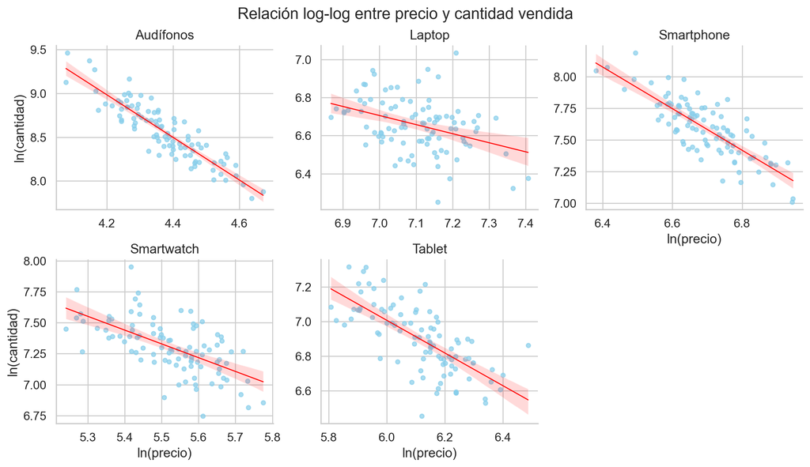

```python
ventas_log = ventas.assign(
    ln_precio=np.log(ventas["precio"]),
    ln_cantidad=np.log(ventas["cantidad"]),
)

g = sns.lmplot(
    data=ventas_log,
    x="ln_precio",
    y="ln_cantidad",
    col="producto",
    col_wrap=3,
    height=3.2,
    aspect=1.2,
    facet_kws={"sharex": False, "sharey": False},
    scatter_kws={"color": "skyblue", "alpha": 0.7, "s": 18},
    line_kws={"color": "red", "linewidth": 1},
)
g.set_titles("{col_name}")
g.set_axis_labels("ln(precio)", "ln(cantidad)")
g.figure.suptitle("Relación log-log entre precio y cantidad vendida", y=1.02)
plt.show()
```

## 1.2 Estimación de la elasticidad

Se estima una regresión con `smf.ols()` por producto. El coeficiente de $\ln(P)$ es la elasticidad. Un ciclo `for` recorre los productos y en cada vuelta:

1. Filtra las ventas del producto.
2. Estima el modelo log-log con `smf.ols().fit()` y lo guarda en el diccionario `ajustes_demanda`.
3. Extrae la elasticidad, su intervalo de confianza, el valor p y el $R^2$, y los agrega como una fila a la lista `filas`, que al final se convierte en la tabla `elasticidades`.

```python
productos = sorted(ventas["producto"].unique())
termino = "np.log(precio)"  # nombre del coeficiente de ln(P) en el modelo

ajustes_demanda = {}  # aquí se guarda el modelo de cada producto
filas = []  # aquí se acumula una fila por producto

for p in productos:
    # 1. Datos del producto
    datos_p = ventas[ventas["producto"] == p]

    # 2. Estimar el modelo log-log
    modelo = smf.ols("np.log(cantidad) ~ np.log(precio)", data=datos_p).fit()
    ajustes_demanda[p] = modelo

    # 3. Extraer los resultados del coeficiente de log(precio)
    ic = modelo.conf_int().loc[termino]

    resultado = {
        "producto": p,
        "elasticidad": modelo.params[termino],
        "conf_low": ic[0],
        "conf_high": ic[1],
        "p_value": modelo.pvalues[termino],
        "r2": modelo.rsquared,
    }
    filas.append(resultado)

elasticidades = pd.DataFrame(filas)
elasticidades
```

|  | producto | elasticidad | conf_low | conf_high | p_value | r2 |
| --- | --- | --- | --- | --- | --- | --- |
| 0 | Audífonos | -2.432 | -2.675 | -2.189 | 1.847e-35 | 0.808 |
| 1 | Laptop | -0.477 | -0.715 | -0.238 | 1.431e-04 | 0.143 |
| 2 | Smartphone | -1.643 | -1.890 | -1.396 | 3.864e-23 | 0.650 |
| 3 | Smartwatch | -1.112 | -1.403 | -0.821 | 2.271e-11 | 0.380 |
| 4 | Tablet | -0.946 | -1.142 | -0.750 | 1.518e-15 | 0.493 |

Este es el resultado completo de `.summary()` para uno de los modelos guardados:

```python
print(ajustes_demanda["Audífonos"].summary())
```

```
                            OLS Regression Results
==============================================================================
Dep. Variable:       np.log(cantidad)   R-squared:                       0.808
Model:                            OLS   Adj. R-squared:                  0.806
Method:                 Least Squares   F-statistic:                     395.8
Date:                Sat, 07 Nov 2026   Prob (F-statistic):           1.85e-35
Time:                        18:09:54   Log-Likelihood:                 50.262
No. Observations:                  96   AIC:                            -96.52
Df Residuals:                      94   BIC:                            -91.39
Df Model:                           1
Covariance Type:            nonrobust
==================================================================================
                     coef    std err          t      P>|t|      [0.025      0.975]
----------------------------------------------------------------------------------
Intercept         19.1992      0.535     35.902      0.000      18.137      20.261
np.log(precio)    -2.4322      0.122    -19.894      0.000      -2.675      -2.189
==============================================================================
Omnibus:                        2.065   Durbin-Watson:                   2.261
Prob(Omnibus):                  0.356   Jarque-Bera (JB):                1.591
Skew:                           0.130   Prob(JB):                        0.451
Kurtosis:                       2.426   Cond. No.                         166.
==============================================================================

Notes:
[1] Standard Errors assume that the covariance matrix of the errors is correctly specified.
```

Todas las elasticidades son negativas y significativas, como predice la **ley de la demanda**. Por ejemplo, para los audífonos un aumento del 1 % en el precio reduce la cantidad vendida en cerca de 2.4 %.

## 1.3 Usar el modelo para la toma de decisión de precios

La pregunta de la gerencia es: **si cambio el precio, ¿qué pasa con el ingreso?** Como el modelo está en logaritmos, todo se puede razonar con **tasas de cambio** (cambios porcentuales), que se suman y se multiplican de forma lineal.

**Paso 1. La elasticidad convierte la tasa del precio en tasa de la cantidad.** En el modelo log-log, un cambio en $\ln(P)$ produce un cambio $E_p$ veces mayor en $\ln(Q)$. Como el cambio en el logaritmo es aproximadamente la tasa de cambio:

$$\%\Delta Q \approx E_p \cdot \%\Delta P$$

**Paso 2. La tasa del ingreso es la suma de las tasas del precio y de la cantidad.** El ingreso es $I = P \cdot Q$; al tomar logaritmos el producto se vuelve una suma, $\ln(I) = \ln(P) + \ln(Q)$, y por tanto:

$$\%\Delta I \approx \%\Delta P + \%\Delta Q$$

**Paso 3. Reemplazar el paso 1 en el paso 2.**

$$\%\Delta I \approx \%\Delta P + E_p \cdot \%\Delta P = (1 + E_p) \cdot \%\Delta P$$

El ingreso cambia en proporción al cambio del precio, y el término $(1 + E_p)$ dice en qué dirección:

| Tipo de demanda | Elasticidad | $1 + E_p$ | Si el precio sube | Decisión |
| --- | --- | --- | --- | --- |
| **Elástica** | $E_p < -1$ | negativo | la cantidad cae más que lo que sube el precio: el ingreso **baja** | Bajar el precio |
| **Inelástica** | $-1 < E_p < 0$ | positivo | la cantidad cae menos que lo que sube el precio: el ingreso **sube** | Subir el precio |

La aproximación es buena para cambios pequeños de precio (alrededor de ±10 %). Para cambios grandes conviene calcular el ingreso con `.predict()`, como en la sección siguiente.

### 1.3.1 Ejemplo con los audífonos

Se aplican los tres pasos con la elasticidad estimada de los audífonos para una subida de precio del 5 %:

```python
cambio_precio = 5  # el precio sube 5 %

cambio_cantidad = e_aud * cambio_precio  # paso 1
cambio_ingreso = cambio_precio + cambio_cantidad  # pasos 2 y 3

pd.DataFrame({
    "elasticidad": [e_aud],
    "%Δ precio": [cambio_precio],
    "%Δ cantidad": [cambio_cantidad],
    "%Δ ingreso": [cambio_ingreso],
}).round(2)
```

|  | elasticidad | %Δ precio | %Δ cantidad | %Δ ingreso |
| --- | --- | --- | --- | --- |
| 0 | -2.43 | 5 | -12.16 | -7.16 |

El precio sube 5 % y la cantidad cae cerca de 12.2 %, así que el ingreso cambia -7.2 %: la demanda de los audífonos es elástica y conviene **bajar** el precio.

### 1.3.2 Todos los productos

Se escribe el paso 3 como una función y se aplica a cada producto:

```python
def cambio_ingreso(cambio_precio, elasticidad):
    return (1 + elasticidad) * cambio_precio


ep = elasticidades["elasticidad"]

pd.DataFrame({
    "producto": elasticidades["producto"],
    "elasticidad": ep.round(2),
    "tipo": np.where(ep < -1, "Elástica", "Inelástica"),
    "%Δ ingreso si el precio sube 5 %": cambio_ingreso(5, ep).round(1),
    "%Δ ingreso si el precio baja 5 %": cambio_ingreso(-5, ep).round(1),
    "recomendacion": np.where(ep < -1, "Bajar precio", "Subir precio"),
})
```

|  | producto | elasticidad | tipo | %Δ ingreso si el precio sube 5 % | %Δ ingreso si el precio baja 5 % | recomendacion |
| --- | --- | --- | --- | --- | --- | --- |
| 0 | Audífonos | -2.43 | Elástica | -7.2 | 7.2 | Bajar precio |
| 1 | Laptop | -0.48 | Inelástica | 2.6 | -2.6 | Subir precio |
| 2 | Smartphone | -1.64 | Elástica | -3.2 | 3.2 | Bajar precio |
| 3 | Smartwatch | -1.11 | Elástica | -0.6 | 0.6 | Bajar precio |
| 4 | Tablet | -0.95 | Inelástica | 0.3 | -0.3 | Subir precio |

Antes de decidir conviene mirar los intervalos de confianza: para Smartwatch y Tablet el intervalo incluye $E_p = -1$, por lo que no se puede afirmar si la demanda es elástica o inelástica y el efecto de un cambio de precio sobre el ingreso es pequeño e incierto.

## 1.4 Pronóstico con el modelo

Con `.predict()` se pronostica la cantidad para un precio nuevo. Por ejemplo, el efecto de bajar 5 % el precio de los audífonos respecto a su precio promedio:

```python
ajuste_audifonos = ajustes_demanda["Audífonos"]

precio_medio = ventas.loc[ventas["producto"] == "Audífonos", "precio"].mean()

escenarios = pd.DataFrame({
    "escenario": ["Precio promedio", "Precio -5 %"],
    "precio": [precio_medio, precio_medio * 0.95],
})

# El modelo predice ln(cantidad); con np.exp() se vuelve a unidades
escenarios["cantidad"] = np.exp(ajuste_audifonos.predict(escenarios))
escenarios["ingreso"] = escenarios["precio"] * escenarios["cantidad"]
escenarios.round(1)
```

|  | escenario | precio | cantidad | ingreso |
| --- | --- | --- | --- | --- |
| 0 | Precio promedio | 79.8 | 5149.6 | 411047.1 |
| 1 | Precio -5 % | 75.8 | 5833.8 | 442380.5 |